# Naive Bayes for Classifying Bills on Immigration

Carlos Ahumada

March 28, 2019

For this task I am going to use dataset on immigration bills from 1947 to 2016 in the U.S. Congress obtained from the [Comparative Agendas Project](https://www.comparativeagendas.net/us). This dataset contains a brief description (usually one sentence) of the topic of the bill, along with other variables such as name of the Legislator who presented the bill, the date, the party, and others. Using a Naive Bayes model, I am going to predict whether a bill was presented by a Republican or a Democrat based on the description.

Since the descriptions contains the main topic of the bills, this algortihm should find enough differences between Democrats and Republicans to correctly classify them.

# Data Preparation

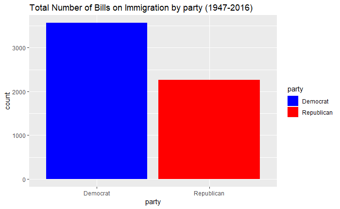

```r
#Visualizing number of bills per party
partybills <- ggplot(data = bills_class) +
  geom_bar(mapping = aes(x = party, fill = party))
partybills <- partybills+scale_fill_manual(values=c("blue", "red"))
partybills + ggtitle("Total Number of Bills on Immigration by party (1947-2016)")
```

As it can be seen in the graph above, there is a class imbalance. There are significantly more bills proposed by Democrat members than by Republicans in this period. For so, a class imbalance solution might be in place. However, this and other modification would be done in the tuning section.

# Naive Bayes model on imbalanced class

First I need to randomize the documents, then prepare the corpus and finally create a document-term-matrix.

```r
#Randomizing rows
set.seed(1628)
bills_imbalanced <- bills_class[sample(row.names (bills_class)), ]
#Creating corpus
bills_corpus <- Corpus(VectorSource(bills_imbalanced$description))
#Creating dtm
bills_dtm <- DocumentTermMatrix(
  bills_corpus,
  control = list(
    tolower = TRUE,
    removeNumbers = FALSE,
    stopwords = TRUE,
    removePunctuation = TRUE
  )
)
```

Now, let’s divide the dtm into train, dev, and test sets.

```r
#Dividing dtm into train, dev and test set. Since a randomization occured before, we can divide directly by rows.
bills_dtm_train <- bills_dtm[1:3228, ] #60% of total observations
bills_dtm_dev <- bills_dtm[3229:4304, ] #20% of total observations
bills_dtm_test <- bills_dtm[4305:5831, ] #20% of total observations
bills_train_labels <- bills_imbalanced[1:3228, ]$party
bills_dev_labels <- bills_imbalanced[3229:4304, ]$party
bills_test_labels <- bills_imbalanced[4305:5831, ]$party
#class balance in training set
bills_train_labels %>%
  table %>%
  prop.table
```

```
.
  Democrat Republican
  0.605948   0.394052
```

In the training set, 60.59% of the bills come from Democrats and 39.41% from Republicans.

```r
#class balance in training set
bills_dev_labels %>%
  table %>%
  prop.table
```

```
.
  Democrat Republican
 0.6050186  0.3949814
```

In the training set, 60.50% of the bills come from Democrats and 39.49% from Republicans.

```r
#class balance in training set
bills_test_labels %>%
  table %>%
  prop.table
```

```
.
  Democrat Republican
 0.6273739  0.3726261
```

Now, it is important to change the count of words for the presence or abscence of words. The Naive Bayes uses this metric to calculate probabilities.

```r
#Converting from numeric (frequencies) to appearing words or not
convert_counts <- function(x) {
  x <- ifelse(x > 0, "Yes", "No")
}
train <- bills_dtm_train %>%
  apply(MARGIN = 2, convert_counts)
dev <- bills_dtm_dev %>%
  apply(MARGIN = 2, convert_counts)
test <- bills_dtm_test %>%
  apply(MARGIN = 2, convert_counts)
```

## Training the classifier

```r
#Training classifier in the test set
bills_classifier <- naiveBayes(train, bills_train_labels)
#Testing the model in the dev set
bills_pred <- predict(bills_classifier, dev)
#Visualizing results in dev set
confusionMatrix(bills_pred, bills_dev_labels, mode = "prec_recall")
```

```
Confusion Matrix and Statistics

            Reference
Prediction   Democrat Republican
  Democrat        481        201
  Republican      170        224

               Accuracy : 0.6552
                 95% CI : (0.6259, 0.6836)
    No Information Rate : 0.605
    P-Value [Acc > NIR] : 0.0003873

                  Kappa : 0.2693
 Mcnemar's Test P-Value : 0.1193465

              Precision : 0.7053
                 Recall : 0.7389
                     F1 : 0.7217
             Prevalence : 0.6050
         Detection Rate : 0.4470
   Detection Prevalence : 0.6338
      Balanced Accuracy : 0.6330

       'Positive' Class : Democrat
```

The acurracy of the model in the dev set is only 65.52%, and reports a F1 score of .7217. It is important to remember that this relatively “good” F1 score might be due to the class imbalance. Now let’s modify the algorithm to see if we can improve the model before running it on the test set. To do so, I am going to apply Laplace smoothing. Laplace smoothing works to get rid of zero probabilities of words in a class that could affect the model.

## Tuning: Naive Bayes with Laplace smoothing on dev set

```r
#Training classifier in the test set with Laplace smoothing
bills_classifier2 <- naiveBayes(train, bills_train_labels, laplace=1)
#Testing the model in the dev set
bills_pred2 <- predict(bills_classifier2, dev)
#Visualizing results in dev set
confusionMatrix(bills_pred2, bills_dev_labels, mode = "prec_recall")
```

```
Confusion Matrix and Statistics

            Reference
Prediction   Democrat Republican
  Democrat        562        228
  Republican       89        197

               Accuracy : 0.7054
                 95% CI : (0.6772, 0.7325)
    No Information Rate : 0.605
    P-Value [Acc > NIR] : 4.272e-12

                  Kappa : 0.3465
 Mcnemar's Test P-Value : 9.128e-15

              Precision : 0.7114
                 Recall : 0.8633
                     F1 : 0.7800
             Prevalence : 0.6050
         Detection Rate : 0.5223
   Detection Prevalence : 0.7342
      Balanced Accuracy : 0.6634

       'Positive' Class : Democrat
```

By applying the Laplace smoothing, the accurcy increases to 70.54%, and the F1 Score to .7800. So the final model to be used for the test set will be the Naive Bayes with Laplace smoothing. Now, let’s appy a class imbalance solution and test again the model.

# Balancing Dataset

## Tuning: Naive Bayes with Laplace smoothing on dev set with balanced class

```r
#class balance in training set
bills_train_labels2 %>%
  table %>%
  prop.table
```

```
.
  Democrat Republican
 0.4988967  0.5011033
```

In the training set, 49.89% of the bills come from Democrats and 50.11% from Republicans.

```r
#class balance in training set
bills_dev_labels2 %>%
  table %>%
  prop.table
```

```
.
  Democrat Republican
 0.4798676  0.5201324
```

In the training set, 47.99% of the bills come from Democrats and 52.01% from Republicans.

```r
#class balance in training set
bills_test_labels2 %>%
  table %>%
  prop.table
```

```
.
  Democrat Republican
 0.5234418  0.4765582
```

In the training set, 52.34% of the bills come from Democrats and 47.66% from Republicans.

## Training classifier on balanced set

```r
#Training classifier in the test set with Laplace smoothing
bills_classifier3 <- naiveBayes(train2, bills_train_labels2, laplace=1)
#Testing the model in the dev set
bills_pred3 <- predict(bills_classifier3, dev2)
#Visualizing results in dev set
confusionMatrix(bills_pred3, bills_dev_labels2, mode = "prec_recall")
```

```
Confusion Matrix and Statistics

            Reference
Prediction   Democrat Republican
  Democrat        768        425
  Republican      102        518

               Accuracy : 0.7093
                 95% CI : (0.6878, 0.7301)
    No Information Rate : 0.5201
    P-Value [Acc > NIR] : < 2.2e-16

                  Kappa : 0.4259
 Mcnemar's Test P-Value : < 2.2e-16

              Precision : 0.6438
                 Recall : 0.8828
                     F1 : 0.7445
             Prevalence : 0.4799
         Detection Rate : 0.4236
   Detection Prevalence : 0.6580
      Balanced Accuracy : 0.7160

       'Positive' Class : Democrat
```

Now, with a balanced datset and a laplace smoothing, the model on the dev set reports a higher acurracy than before with 70.93%. However, the F1 score also decreased to .7445. Now, after tunning the model, let’s assess its performance on the test set.

# Final Model on Test Set

```r
#Testing the model in the dev set
bills_pred4 <- predict(bills_classifier3, test2)
#Visualizing results in dev set
confusionMatrix(bills_pred4, bills_test_labels2, mode = "prec_recall")
```

```
Confusion Matrix and Statistics

            Reference
Prediction   Democrat Republican
  Democrat        815        356
  Republican      134        508

               Accuracy : 0.7297
                 95% CI : (0.7087, 0.7501)
    No Information Rate : 0.5234
    P-Value [Acc > NIR] : < 2.2e-16

                  Kappa : 0.452
 Mcnemar's Test P-Value : < 2.2e-16

              Precision : 0.6960
                 Recall : 0.8588
                     F1 : 0.7689
             Prevalence : 0.5234
         Detection Rate : 0.4495
   Detection Prevalence : 0.6459
      Balanced Accuracy : 0.7234

       'Positive' Class : Democrat
```

The model has a final acurracy of 72.97%, and reports a F1 score of 76.89%. This means that the model correctly classifies which party presented the a bill on immigration 73 out of 100 times, depending on the description of the bill.